# Lab 1 - Exploring Data

## Using the summary() function to see how many elite universities there are. And plotting boxplot to produce side-by-side boxplots of Outstate versus Elite.

Printing summary

```r
summary(college$Elite)
```

```
##  No Yes
## 699  78
```

Printing the boxplot of Outstate versus Elite

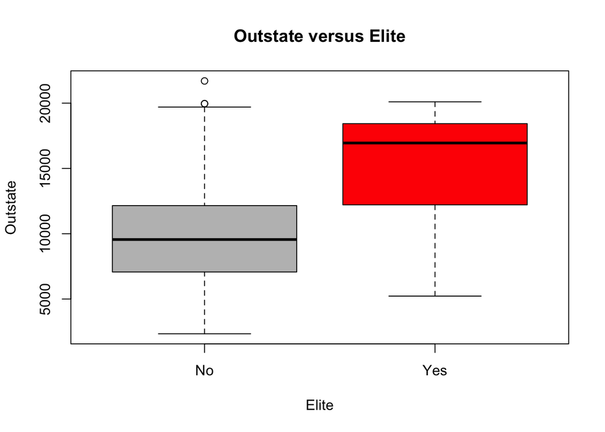

```r
boxplot(college$Outstate ~ college$Elite, col = c("Grey", "Red"), main = "Outstate versus Elite", xlab = "Elite", ylab = "Outstate")
```

## Printing the Histograms of few of the quantitative variables with different values of break or with different binning

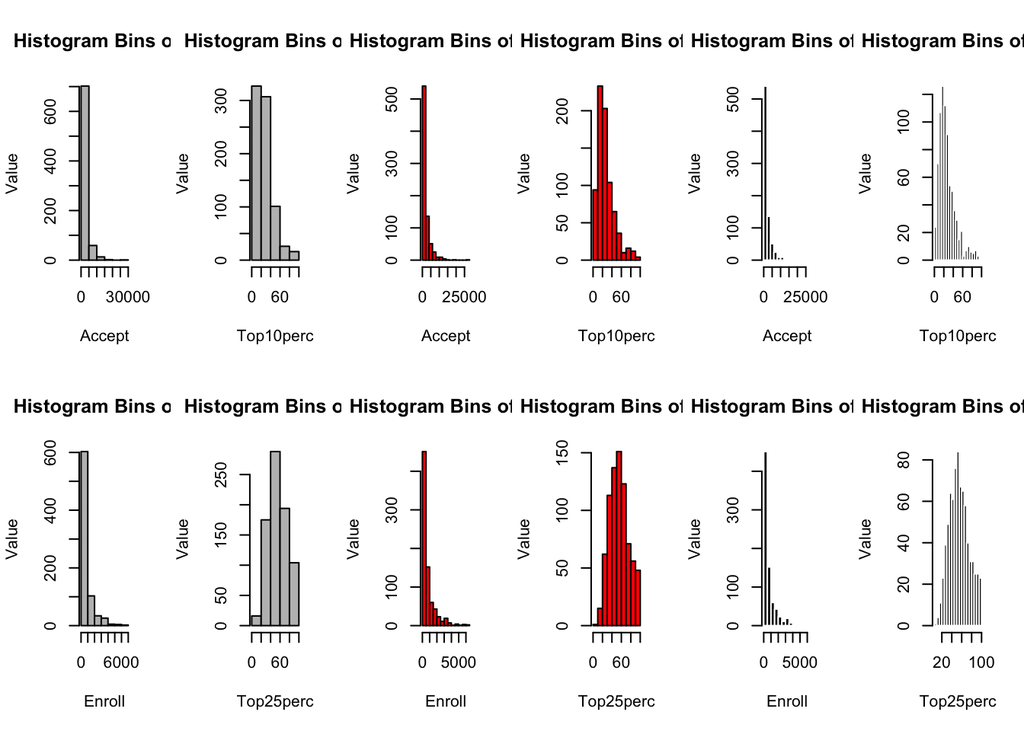

```r
#Dividing the window
par(mfcol = c(2,6))

#Quantitative Variables with 5 bins
hist(college$Accept, breaks = 5, freq = TRUE, col = "Grey", main = "Histogram Bins of 5",
    xlab = "Accept", ylab = "Value")
hist(college$Enroll, breaks = 5, freq = TRUE, col = "Grey", main = "Histogram Bins of 5",
    xlab = "Enroll", ylab = "Value")
hist(college$Top10perc, breaks = 5, freq = TRUE, col = "Grey", main = "Histogram Bins of 5",
    xlab = "Top10perc", ylab = "Value")
hist(college$Top25perc, breaks = 5, freq = TRUE, col = "Grey", main = "Histogram Bins of 5",
    xlab = "Top25perc", ylab = "Value")

#Quantitative Variables with 10 bins
hist(college$Accept, breaks = 10, freq = TRUE, col = "Red", main = "Histogram Bins of 10",
    xlab = "Accept", ylab = "Value")
hist(college$Enroll, breaks = 10, freq = TRUE, col = "Red", main = "Histogram Bins of 10",
    xlab = "Enroll", ylab = "Value")
hist(college$Top10perc, breaks = 10, freq = TRUE, col = "Red", main = "Histogram Bins of 10",
    xlab = "Top10perc", ylab = "Value")
hist(college$Top25perc, breaks = 10, freq = TRUE, col = "Red", main = "Histogram Bins of 10",
    xlab = "Top25perc", ylab = "Value")

#Quantitative Variables with 15 bins
hist(college$Accept, breaks = 15, freq = TRUE, col = "Black", border = "White", main = "Histogram Bins of 15",
    xlab = "Accept", ylab = "Value")
hist(college$Enroll, breaks = 15, freq = TRUE, col = "Black", border = "White", main = "Histogram Bins of 15",
    xlab = "Enroll", ylab = "Value")
hist(college$Top10perc, breaks = 15, freq = TRUE, col = "Black", border = "White", main = "Histogram Bins of 15",
    xlab = "Top10perc", ylab = "Value")
hist(college$Top25perc, breaks = 15, freq = TRUE, col = "Black", border = "White", main = "Histogram Bins of 15",
    xlab = "Top25perc", ylab = "Value")
```

## Summary to find qualitative (categorical) and quantitative predictors

```r
summary(college)
```

```
##  Private        Apps           Accept          Enroll       Top10perc
##  No :212   Min.   :   81   Min.   :   72   Min.   :  35   Min.   : 1.00
##  Yes:565   1st Qu.:  776   1st Qu.:  604   1st Qu.: 242   1st Qu.:15.00
##            Median : 1558   Median : 1110   Median : 434   Median :23.00
##            Mean   : 3002   Mean   : 2019   Mean   : 780   Mean   :27.56
##            3rd Qu.: 3624   3rd Qu.: 2424   3rd Qu.: 902   3rd Qu.:35.00
##            Max.   :48094   Max.   :26330   Max.   :6392   Max.   :96.00
##    Top25perc      F.Undergrad     P.Undergrad         Outstate
##  Min.   :  9.0   Min.   :  139   Min.   :    1.0   Min.   : 2340
##  1st Qu.: 41.0   1st Qu.:  992   1st Qu.:   95.0   1st Qu.: 7320
##  Median : 54.0   Median : 1707   Median :  353.0   Median : 9990
##  Mean   : 55.8   Mean   : 3700   Mean   :  855.3   Mean   :10441
##  3rd Qu.: 69.0   3rd Qu.: 4005   3rd Qu.:  967.0   3rd Qu.:12925
##  Max.   :100.0   Max.   :31643   Max.   :21836.0   Max.   :21700
##    Room.Board       Books           Personal         PhD
##  Min.   :1780   Min.   :  96.0   Min.   : 250   Min.   :  8.00
##  1st Qu.:3597   1st Qu.: 470.0   1st Qu.: 850   1st Qu.: 62.00
##  Median :4200   Median : 500.0   Median :1200   Median : 75.00
##  Mean   :4358   Mean   : 549.4   Mean   :1341   Mean   : 72.66
##  3rd Qu.:5050   3rd Qu.: 600.0   3rd Qu.:1700   3rd Qu.: 85.00
##  Max.   :8124   Max.   :2340.0   Max.   :6800   Max.   :103.00
##     Terminal       S.F.Ratio      perc.alumni        Expend
##  Min.   : 24.0   Min.   : 2.50   Min.   : 0.00   Min.   : 3186
##  1st Qu.: 71.0   1st Qu.:11.50   1st Qu.:13.00   1st Qu.: 6751
##  Median : 82.0   Median :13.60   Median :21.00   Median : 8377
##  Mean   : 79.7   Mean   :14.09   Mean   :22.74   Mean   : 9660
##  3rd Qu.: 92.0   3rd Qu.:16.50   3rd Qu.:31.00   3rd Qu.:10830
##  Max.   :100.0   Max.   :39.80   Max.   :64.00   Max.   :56233
##    Grad.Rate      Elite
##  Min.   : 10.00   No :699
##  1st Qu.: 53.00   Yes: 78
##  Median : 65.00
##  Mean   : 65.46
##  3rd Qu.: 78.00
##  Max.   :118.00
```

As can be seen from the above summary Elite and Private are the 2 Predictors that are categorical or we can say qualitative and have the options Yes and No. All other which includes Apps, Accept, Enroll, Top10perc, Top25perce, F.Undergrad, P.Undergrad, Outstate, Room.Board, Books, Personal, PhD, Terminal, S.F.Ration, perc.alumni, Expend, Grad.Rate are quantitative.

Please note: Originally, we had only 1 qualitative that is Private. But, after binning Top10perc we created another qualitative variable that is Elite.

## Finding Range, Mean and Standard deviation of Enroll

```r
#Range of Enroll: Finds the min and max value and stores it in a numeric vector
range <- range(college$Enroll)
#We will take the difference of the max and the min value to get the range
diff(range)
```

```
## [1] 6357
```

```r
#Find mean of Enroll
mean(college$Enroll)
```

```
## [1] 779.973
```

```r
#Find standard deviation of Enroll
sd(college$Enroll)
```

```
## [1] 929.1762
```

## Removing rows and finding Range, Mean, Standard deviation

Removing 100th through 200th observations from the college dataframe and storing in a new dataframe (so that we don’t loose the observations in original dataframe) and then again finding Range, Mean and Standard deviation of Enroll in the subset of data that remains.

```r
#Removing 100th to 200th observations from the college dataframe and storing it as a college_new_df dataframe
college_new_df <- college[-(100:200), ]
#Range of Enroll: Finds the min and max value and stores it in a numeric vector
range_new_df <- range(college_new_df$Enroll)
#We will take the difference of the max and the min value to get the range
diff(range_new_df)
```

```
## [1] 6357
```

```r
#Find mean of Enroll in the college_new_df dataframe
mean(college_new_df$Enroll)
```

```
## [1] 823.0695
```

```r
#Find standard deviation of Enroll in the college_new_df dataframe
sd(college_new_df$Enroll)
```

```
## [1] 972.2258
```

Here we are not creating a new dataframe

```r
#Removing 100th to 200th observations from the college dataframe and storing it as a college_new_df dataframe
college[-(100:200), ]
fix(college)
#Range of Enroll: Finds the min and max value and stores it in a numeric vector
range <- range(college$Enroll)
#We will take the difference of the max and the min value to get the range
diff(range)
#Find mean of Enroll in the college_new_df dataframe
mean(college$Enroll)
#Find standard deviation of Enroll in the college_new_df dataframe
sd(college$Enroll)
```

[output not shown]